# Introduction to bvhar

```r
library(bvhar)
```

# Data

Looking at VAR and VHAR, you can learn how the models work and how to perform this package.

## ETF Dataset

This package includes some datasets. Among them, we try CBOE ETF volatility index (`etf_vix`). Since this is just an example, we arbitrarily extract a small number of variables: *Gold, crude oil, euro currency, and china ETF*.

```r
var_idx <- c("GVZCLS", "OVXCLS", "EVZCLS", "VXFXICLS")
etf <-
  etf_vix %>%
  dplyr::select(dplyr::all_of(var_idx))
etf
```

```
#> # A tibble: 905 × 4
#>    GVZCLS OVXCLS EVZCLS VXFXICLS
#>     <dbl>  <dbl>  <dbl>    <dbl>
#>  1   21.5   36.5   13.2     30.2
#>  2   21.5   35.4   12.6     28.9
#>  3   22.3   35.5   13.1     29.1
#>  4   21.6   36.6   12.8     28.5
#>  5   21.2   35.6   13.3     29.5
#>  6   21.4   34.8   13.2     29.1
#>  7   21.6   34.0   13.2     28.7
#>  8   21.1   32.6   12.8     28.0
#>  9   20.3   33.5   12.7     28.9
#> 10   19.6   33.4   12.4     28.0
#> # ℹ 895 more rows
```

## h-step ahead forecasting

For evaluation, split the data. The last `19` observations will be test set. `divide_ts()` function splits the time series into train-test set.

In the other vignette, we provide how to perform out-of-sample forecasting.

```r
h <- 19
etf_eval <- divide_ts(etf, h) # Try ?divide_ts
etf_train <- etf_eval$train # train
etf_test <- etf_eval$test # test
# dimension---------
m <- ncol(etf)
```

- T: Total number of observation
- p: VAR lag
- m: Dimension of variable
- s = T - p
- k = m * p + 1 if constant term, k = m * p without constant term

# Models

## VAR

This package indentifies VAR(p) model by

$$\mathbf{Y}_t = \mathbf{c}+
\boldsymbol\beta_1 \mathbf{Y}_{t - 1} + \ldots + \boldsymbol\beta_p
+\mathbf{Y}_{t - p} + \boldsymbol\epsilon_t$$

where $\boldsymbol\epsilon_t \sim N(\mathbf{0}_k, \Sigma_e)$

```r
var_lag <- 5
```

The package perform VAR(p = 5) based on

$$Y_0 = X_0 A + Z$$

where

$$Y_0 = \begin{bmatrix}
\mathbf{y}_{p + 1}^T \\
\mathbf{y}_{p + 2}^T \\
\vdots \\
\mathbf{y}_n^T
\end{bmatrix}_{s \times m} \equiv Y_{p + 1} \in \mathbb{R}^{s \times m}$$

by `build_y0()`

and

$$X_0 = \left[\begin{array}{c|c|c|c}
\mathbf{y}_p^T & \cdots & \mathbf{y}_1^T & 1 \\
\mathbf{y}_{p + 1}^T & \cdots & \mathbf{y}_2^T & 1 \\
\vdots & \vdots & \cdots & \vdots \\
\mathbf{y}_{T - 1}^T & \cdots & \mathbf{y}_{T - p}^T & 1
\end{array}\right]_{s \times k} = \begin{bmatrix}
Y_p & Y_{p - 1} & \cdots & \mathbf{1}_{T - p}
\end{bmatrix} \in \mathbb{R}^{s \times k}$$

by `build_design()`. Coefficient matrix is the form of

$$A = \begin{bmatrix}
A_1^T \\
\vdots \\
A_p^T \\
\mathbf{c}^T
\end{bmatrix} \in \mathbb{R}^{k \times m}$$

This form also corresponds to the other model. Use `var_lm(y, p)` to model VAR(p). You can specify `type = "none"` to get model without constant term.

```r
(fit_var <- var_lm(etf_train, var_lag))
```

```
#> Call:
#> var_lm(y = etf_train, p = var_lag)
#>
#> VAR(5) Estimation using least squares
#> ====================================================
#>
#> LSE for A1:
#>           GVZCLS_1  OVXCLS_1  EVZCLS_1  VXFXICLS_1
#> GVZCLS     0.93290    0.0545    0.0659     -0.0346
#> OVXCLS    -0.02367    1.0047   -0.1447      0.0324
#> EVZCLS    -0.00789    0.0102    0.9810      0.0199
#> VXFXICLS  -0.03868    0.0109    0.0754      0.9328
#>
#>
#> LSE for A2:
#>           GVZCLS_2  OVXCLS_2  EVZCLS_2  VXFXICLS_2
#> GVZCLS     -0.0781  -0.04865    0.0829      0.0561
#> OVXCLS      0.0880   0.01207    0.2729     -0.1173
#> EVZCLS      0.0195   0.00255   -0.1071     -0.0383
#> VXFXICLS    0.0896   0.04278   -0.0691      0.0419
#>
#>
#> LSE for A3:
#>           GVZCLS_3  OVXCLS_3  EVZCLS_3  VXFXICLS_3
#> GVZCLS      0.0424  -0.00452  -0.03245    -0.05967
#> OVXCLS     -0.0272  -0.09144  -0.05764    -0.06255
#> EVZCLS     -0.0123   0.00864   0.08693     0.00252
#> VXFXICLS   -0.0266  -0.04810   0.00851    -0.02137
#>
#>
#> LSE for A4:
#>           GVZCLS_4  OVXCLS_4  EVZCLS_4  VXFXICLS_4
#> GVZCLS    -0.00793   0.01072  -0.01513      0.0616
#> OVXCLS    -0.04343  -0.00377  -0.00694      0.1445
#> EVZCLS     0.00614  -0.02278  -0.01007      0.0200
#> VXFXICLS  -0.00755  -0.05555   0.08783     -0.1025
#>
#>
#> LSE for A5:
#>           GVZCLS_5  OVXCLS_5  EVZCLS_5  VXFXICLS_5
#> GVZCLS      0.0728  -0.01745   -0.0886   -0.017273
#> OVXCLS      0.0104   0.07151   -0.0637    0.002018
#> EVZCLS     -0.0113   0.00581    0.0202    0.000498
#> VXFXICLS   -0.0155   0.04192   -0.0254    0.093984
#>
#>
#> LSE for constant:
#>   GVZCLS    OVXCLS    EVZCLS  VXFXICLS
#>    0.571     0.145     0.129     0.875
#>
#>
#> --------------------------------------------------
#> *_j of the Coefficient matrix: corresponding to the j-th VAR lag
```

The package provide `S3` object.

```r
# class---------------
class(fit_var)
```

```
#> [1] "varlse"   "bvharmod"
```

```r
# inheritance---------
is.varlse(fit_var)
```

```
#> [1] TRUE
```

```r
# names---------------
names(fit_var)
```

```
#>  [1] "coefficients"  "fitted.values" "residuals"     "covmat"
#>  [5] "df"            "m"             "obs"           "y0"
#>  [9] "p"             "totobs"        "process"       "type"
#> [13] "design"        "y"             "call"
```

## VHAR

Consider Vector HAR (VHAR) model.

$$\mathbf{Y}_t = \mathbf{c}+ \Phi^{(d)} +
\mathbf{Y}_{t - 1} + \Phi^{(w)} \mathbf{Y}_{t - 1}^{(w)} + \Phi^{(m)}
\mathbf{Y}_{t - 1}^{(m)} + \boldsymbol\epsilon_t$$

where $\mathbf{Y}_t$ is daily RV and

$$\mathbf{Y}_t^{(w)} = \frac{1}{5} \left(
\mathbf{Y}_t + \cdots + \mathbf{Y}_{t - 4} \right)$$

is weekly RV

and

$$\mathbf{Y}_t^{(m)} = \frac{1}{22} \left(
\mathbf{Y}_t + \cdots + \mathbf{Y}_{t - 21} \right)$$

is monthly RV. This model can be expressed by

$$Y_0 = X_1 \Phi + Z$$

where

$$\Phi = \begin{bmatrix}
\Phi^{(d)T} \\
\Phi^{(w)T} \\
\Phi^{(m)T} \\
\mathbf{c}^T
\end{bmatrix} \in \mathbb{R}^{(3m + 1) \times m}$$

Let $T$ be

$$\mathbb{C}_0 \mathpunct{:}=\begin{bmatrix}
1 & 0 & \cdots & 0 & 0 & \cdots & 0 \\
1 / 5 & 1 / 5 & \cdots & 1 / 5 & 0 & \cdots &
0 \\
1 / 22 & 1 / 22 & \cdots & 1 / 22 & 1 / 22 &
\cdots & 1 / 22
\end{bmatrix} \otimes I_m \in \mathbb{R}^{3m \times 22m}$$

and let $\mathbb{C}_{HAR}$ be

$$\mathbb{C}_{HAR} \mathpunct{:}=\left[\begin{array}{c|c}
T & \mathbf{0}_{3m} \\ \hline
\mathbf{0}_{3m}^T & 1
\end{array}\right] \in \mathbb{R}^{(3m + 1) \times (22m + 1)}$$

Then for $X_0$ in VAR(p),

$$X_1 = X_0 \mathbb{C}_{HAR}^T = \begin{bmatrix}
\mathbf{y}_{22}^T & \mathbf{y}_{22}^{(w)T} &
\mathbf{y}_{22}^{(m)T} & 1 \\
\mathbf{y}_{23}^T & \mathbf{y}_{23}^{(w)T} &
\mathbf{y}_{23}^{(m)T} & 1 \\
\vdots & \vdots & \vdots & \vdots \\
\mathbf{y}_{T - 1}^T & \mathbf{y}_{T - 1}^{(w)T} &
\mathbf{y}_{T - 1}^{(m)T} & 1
\end{bmatrix} \in \mathbb{R}^{s \times (3m + 1)}$$

This package fits VHAR by scaling VAR(p) using $\mathbb{C}_{HAR}$ (`scale_har(m, week = 5, month = 22)`). Use `vhar_lm(y)` to fit VHAR. You can specify `type = "none"` to get model without constant term.

```r
(fit_har <- vhar_lm(etf_train))
```

```
#> Call:
#> vhar_lm(y = etf_train)
#>
#> VHAR Estimation====================================================
#>
#> LSE for day:
#>           GVZCLS_day  OVXCLS_day  EVZCLS_day  VXFXICLS_day
#> GVZCLS       0.87561      0.0447      0.1623      -0.03772
#> OVXCLS       0.04147      0.9942     -0.0605      -0.09361
#> EVZCLS       0.00305      0.0281      0.9206      -0.00748
#> VXFXICLS     0.01021      0.0569      0.0440       0.91713
#>
#>
#> LSE for week:
#>           GVZCLS_week  OVXCLS_week  EVZCLS_week  VXFXICLS_week
#> GVZCLS        0.01622      -0.0554      -0.1608         0.0637
#> OVXCLS       -0.07093      -0.0373       0.2000         0.1034
#> EVZCLS       -0.00334      -0.0414      -0.0101         0.0239
#> VXFXICLS     -0.03756      -0.0787      -0.0135         0.0480
#>
#>
#> LSE for month:
#>           GVZCLS_month  OVXCLS_month  EVZCLS_month  VXFXICLS_month
#> GVZCLS        0.084981       0.00359        0.0228         -0.0299
#> OVXCLS        0.045986       0.03825       -0.1564         -0.0157
#> EVZCLS       -0.000597       0.02030        0.0501         -0.0138
#> VXFXICLS      0.041648       0.01263        0.0639         -0.0371
#>
#>
#> LSE for constant:
#>   GVZCLS    OVXCLS    EVZCLS  VXFXICLS
#>    0.491     0.135     0.105     0.926
#>
#>
#> --------------------------------------------------
#> *_day, *_week, *_month of the Coefficient matrix: daily, weekly, and monthly term in the VHAR model
```

```r
# class----------------
class(fit_har)
```

```
#> [1] "vharlse"  "bvharmod"
```

```r
# inheritance----------
is.varlse(fit_har)
```

```
#> [1] FALSE
```

```r
is.vharlse(fit_har)
```

```
#> [1] TRUE
```

```r
# complements----------
names(fit_har)
```

```
#>  [1] "coefficients"  "fitted.values" "residuals"     "covmat"
#>  [5] "df"            "m"             "obs"           "y0"
#>  [9] "p"             "week"          "month"         "totobs"
#> [13] "process"       "type"          "HARtrans"      "design"
#> [17] "y"             "call"
```

## BVAR

`bvhar` package provides two prior framework - Minnesota prior and flat prior.

### Minnesota prior

- Litterman (1986) and Bańbura et al. (2010)
- All the equations are centered around the random walk with drift.
- *Prior mean*: Recent lags provide more reliable information than the more distant ones.
- *Prior variance*: Own lags explain more of the variation of a given variable than the lags of other variables in the equation.

First specify the prior using `set_bvar(sigma, lambda, delta, eps = 1e-04)`.

```r
bvar_lag <- 5
sig <- apply(etf_train, 2, sd) # sigma vector
lam <- .2 # lambda
delta <- rep(0, m) # delta vector (0 vector since RV stationary)
eps <- 1e-04 # very small number
(bvar_spec <- set_bvar(sig, lam, delta, eps))
```

```
#> Model Specification for BVAR
#>
#> Parameters: Coefficent matrice and Covariance matrix
#> Prior: Minnesota
#> # Type '?bvar_minnesota' in the console for some help.
#> ========================================================
#>
#> Setting for 'sigma':
#>   GVZCLS    OVXCLS    EVZCLS  VXFXICLS
#>     3.77     10.63      2.27      3.81
#>
#> Setting for 'lambda':
#> [1]  0.2
#>
#> Setting for 'delta':
#> [1]  0  0  0  0
#>
#> Setting for 'eps':
#> [1]  1e-04
```

In turn, `bvar_minnesota(y, p, bayes_spec, include_mean = TRUE)` fits BVAR(p).

- `y`: Multivariate time series data. It should be data frame or matrix, which means that every column is numeric. Each column indicates variable, i.e. it sould be wide format.
- `p`: Order of BVAR
- `bayes_spec`: Output of `set_bvar()`
- `include_mean = TRUE`: By default, you include the constant term in the model.

```r
(fit_bvar <- bvar_minnesota(etf_train, bvar_lag, bvar_spec))
```

```
#> Call:
#> bvar_minnesota(y = etf_train, p = bvar_lag, bayes_spec = bvar_spec)
#>
#> BVAR(5) with Minnesota Prior
#> ====================================================
#>
#> A ~ Matrix Normal (Mean, Precision, Scale = Sigma)
#> ====================================================
#> Matrix Normal Mean for A1 part:
#>           GVZCLS_1  OVXCLS_1  EVZCLS_1  VXFXICLS_1
#> GVZCLS      0.7771   0.00915    0.0628      0.0193
#> OVXCLS      0.0445   0.70884    0.1111      0.0167
#> EVZCLS      0.0104   0.01068    0.7036      0.0266
#> VXFXICLS    0.0214   0.00673    0.1044      0.7674
#>
#>
#> Matrix Normal Mean for A2 part:
#>            GVZCLS_2   OVXCLS_2  EVZCLS_2  VXFXICLS_2
#> GVZCLS     0.082726  -0.006736  -0.01387     -0.0020
#> OVXCLS     0.000568   0.140781   0.02419     -0.0436
#> EVZCLS    -0.004778   0.000769   0.11756     -0.0114
#> VXFXICLS   0.013424  -0.003779   0.00369      0.1063
#>
#>
#> Matrix Normal Mean for A3 part:
#>           GVZCLS_3   OVXCLS_3  EVZCLS_3  VXFXICLS_3
#> GVZCLS     0.03574  -0.003825  -0.01504    -0.00581
#> OVXCLS    -0.01733   0.054037   0.00196    -0.01874
#> EVZCLS    -0.00391   0.000223   0.05065    -0.00168
#> VXFXICLS  -0.00891  -0.006167  -0.00435     0.02176
#>
#>
#> Matrix Normal Mean for A4 part:
#>           GVZCLS_4   OVXCLS_4   EVZCLS_4  VXFXICLS_4
#> GVZCLS     0.02474  -0.001932  -0.011546     0.00263
#> OVXCLS    -0.00987   0.030763   0.003771     0.00845
#> EVZCLS    -0.00318  -0.000206   0.027289     0.00161
#> VXFXICLS  -0.00898  -0.004378   0.000232     0.00582
#>
#>
```

[output cut: 17 more lines]

```
#> Sigma ~ Inverse-Wishart
#> ====================================================
#> IW scale matrix:
#>           GVZCLS  OVXCLS  EVZCLS  VXFXICLS
#> GVZCLS      1285     375     115       287
#> OVXCLS       375    3638     131       397
#> EVZCLS       115     131     220       126
#> VXFXICLS     287     397     126      1186
#>
#> IW degrees of freedom:
#> [1] 887
#>
#>
#> --------------------------------------------------
#> *_j of the Coefficient matrix: corresponding to the j-th BVAR lag
```

It is `bvarmn` class. For Bayes computation, it also has other class such as `normaliw` and `bvharmod`.

```r
# class---------------
class(fit_bvar)
```

```
#> [1] "bvarmn"   "normaliw" "bvharmod"
```

```r
# inheritance---------
is.bvarmn(fit_bvar)
```

```
#> [1] TRUE
```

```r
# names---------------
names(fit_bvar)
```

```
#>  [1] "coefficients"    "fitted.values"   "residuals"       "mn_prec"
#>  [5] "iw_scale"        "iw_shape"        "df"              "m"
#>  [9] "obs"             "prior_mean"      "prior_precision" "prior_scale"
#> [13] "prior_shape"     "y0"              "design"          "p"
#> [17] "totobs"          "type"            "y"               "prior_prec"
#> [21] "call"            "process"         "spec"
```

### Flat prior

Ghosh et al. (2018) provides flat prior for covariance matrix, i.e. non-informative. Use `set_bvar_flat(U)`.

```r
(flat_spec <- set_bvar_flat(U = 5000 * diag(m * bvar_lag + 1))) # c * I
```

```
#> Model Specification for BVAR
#>
#> Parameters: Coefficent matrice and Covariance matrix
#> Prior: Flat
#> # Type '?bvar_flat' in the console for some help.
#> ========================================================
#>
#> Setting for 'U':
#> # A matrix:  21 x 21
#>        [,1]  [,2]  [,3]  [,4]  [,5]
#>  [1,]  5000     0     0     0     0
#>  [2,]     0  5000     0     0     0
#>  [3,]     0     0  5000     0     0
#>  [4,]     0     0     0  5000     0
#>  [5,]     0     0     0     0  5000
#>  [6,]     0     0     0     0     0
#>  [7,]     0     0     0     0     0
#>  [8,]     0     0     0     0     0
#>  [9,]     0     0     0     0     0
#> [10,]     0     0     0     0     0
#> # ... with 11 more rows
```

Then `bvar_flat(y, p, bayes_spec, include_mean = TRUE)`:

```r
(fit_ghosh <- bvar_flat(etf_train, bvar_lag, flat_spec))
```

```
#> Call:
#> bvar_flat(y = etf_train, p = bvar_lag, bayes_spec = flat_spec)
#>
#> BVAR(5) with Flat Prior
#> ====================================================
#>
#> A ~ Matrix Normal (Mean, U^{-1}, Scale 2 = Sigma)
#> ====================================================
#> Matrix Normal Mean for A1 part:
#>           GVZCLS_1  OVXCLS_1  EVZCLS_1  VXFXICLS_1
#> GVZCLS      0.3128    0.0460    0.0205      0.0457
#> OVXCLS      0.0440    0.4128    0.0186      0.0314
#> EVZCLS      0.0174    0.0230    0.1334      0.0410
#> VXFXICLS    0.0477    0.0464    0.0481      0.3197
#>
#>
#> Matrix Normal Mean for A2 part:
#>           GVZCLS_2  OVXCLS_2  EVZCLS_2  VXFXICLS_2
#> GVZCLS     0.19811   0.00287   0.00771      0.0194
#> OVXCLS     0.01595   0.23709   0.00978     -0.0111
#> EVZCLS     0.00425   0.01205   0.11715      0.0201
#> VXFXICLS   0.02725   0.01516   0.03513      0.2162
#>
#>
#> Matrix Normal Mean for A3 part:
#>           GVZCLS_3  OVXCLS_3  EVZCLS_3  VXFXICLS_3
#> GVZCLS     0.13884   -0.0153  -0.00102     0.00591
#> OVXCLS    -0.00741    0.1304   0.00361    -0.02452
#> EVZCLS    -0.00353    0.0079   0.10724     0.01150
#> VXFXICLS   0.00797   -0.0146   0.02633     0.14628
#>
#>
#> Matrix Normal Mean for A4 part:
#>           GVZCLS_4  OVXCLS_4  EVZCLS_4  VXFXICLS_4
#> GVZCLS     0.11392  -0.01775  -0.00653     0.00884
#> OVXCLS    -0.01626   0.09421   0.00195    -0.00572
#> EVZCLS    -0.00847   0.00565   0.10046     0.01098
#> VXFXICLS  -0.00356  -0.03067   0.02292     0.10552
#>
#>
```

[output cut: 14 more lines]

```
#> [1]  21  21
#>
#>
#> Sigma ~ Inverse-Wishart
#> ====================================================
#> IW scale matrix:
#>           GVZCLS  OVXCLS  EVZCLS  VXFXICLS
#> GVZCLS      2483     595     209       535
#> OVXCLS       595    3580     216       578
#> EVZCLS       209     216     771       354
#> VXFXICLS     535     578     354      2472
#>
#>
#> --------------------------------------------------
#> *_j of the Coefficient matrix: corresponding to the j-th BVAR lag
```

```r
# class---------------
class(fit_ghosh)
```

```
#> [1] "bvarflat" "normaliw" "bvharmod"
```

```r
# inheritance---------
is.bvarflat(fit_ghosh)
```

```
#> [1] TRUE
```

```r
# names---------------
names(fit_ghosh)
```

```
#>  [1] "coefficients"    "fitted.values"   "residuals"       "mn_prec"
#>  [5] "iw_scale"        "iw_shape"        "df"              "p"
#>  [9] "m"               "obs"             "totobs"          "process"
#> [13] "spec"            "type"            "call"            "prior_mean"
#> [17] "prior_precision" "y0"              "design"          "y"
```

## BVHAR

Consider the VAR(22) form of VHAR.

$$\begin{aligned}
\mathbf{Y}_t = \mathbf{c}& + \left( \Phi^{(d)} + \frac{1}{5}
\Phi^{(w)} + \frac{1}{22} \Phi^{(m)} \right) \mathbf{Y}_{t - 1} \\
& + \left( \frac{1}{5} \Phi^{(w)} + \frac{1}{22} \Phi^{(m)}
\right) \mathbf{Y}_{t - 2} + \cdots \left( \frac{1}{5} \Phi^{(w)} +
\frac{1}{22} \Phi^{(m)} \right) \mathbf{Y}_{t - 5} \\
& + \frac{1}{22} \Phi^{(m)} \mathbf{Y}_{t - 6} + \cdots +
\frac{1}{22} \Phi^{(m)} \mathbf{Y}_{t - 22}
\end{aligned}$$

What does Minnesota prior mean in VHAR model?

- All the equations are centered around $\mathbf{Y}_t + \mathbf{c}+ \Phi^{(d)} \mathbf{Y}_{t - 1} + \boldsymbol\epsilon_t$
- RW form: shrink diagonal elements of $\Phi^{(d)}$ toward one
  - $\Phi^{(w)}$ and $\Phi^{(m)}$ to zero
- WN form: $\delta_i = 0$

For more simplicity, write coefficient matrices by $\Phi^{(1)}, \Phi^{(2)}, \Phi^{(3)}$. If we apply the prior in the same way, Minnesota moment becomes

$$E \left[ (\Phi^{(l)})_{ij} \right] = \begin{cases}
\delta_i & j = i, \; l = 1 \\
0 & o/w
\end{cases} \quad \mathrm{Var}\left[ (\Phi^{(l)})_{ij} \right] =
\begin{cases}
\frac{\lambda^2}{l^2} & j = i \\
\nu \frac{\lambda^2}{l^2} \frac{\sigma_i^2}{\sigma_j^2} & o/w
\end{cases}$$

We call this VAR-type Minnesota prior or BVHAR-S.

### BVHAR-S

`set_bvhar(sigma, lambda, delta, eps = 1e-04)` specifies VAR-type Minnesota prior.

```r
(bvhar_spec_v1 <- set_bvhar(sig, lam, delta, eps))
```

```
#> Model Specification for BVHAR
#>
#> Parameters: Coefficent matrice and Covariance matrix
#> Prior: MN_VAR
#> # Type '?bvhar_minnesota' in the console for some help.
#> ========================================================
#>
#> Setting for 'sigma':
#>   GVZCLS    OVXCLS    EVZCLS  VXFXICLS
#>     3.77     10.63      2.27      3.81
#>
#> Setting for 'lambda':
#> [1]  0.2
#>
#> Setting for 'delta':
#> [1]  0  0  0  0
#>
#> Setting for 'eps':
#> [1]  1e-04
```

`bvhar_minnesota(y, har = c(5, 22), bayes_spec, include_mean = TRUE)` can fit BVHAR with this prior. This is the default prior setting.

```r
(fit_bvhar_v1 <- bvhar_minnesota(etf_train, bayes_spec = bvhar_spec_v1))
```

```
#> Call:
#> bvhar_minnesota(y = etf_train, bayes_spec = bvhar_spec_v1)
#>
#> BVHAR with Minnesota Prior
#> ====================================================
#>
#> Phi ~ Matrix Normal (Mean, Scale 1, Scale 2 = Sigma)
#> ====================================================
#> Matrix Normal Mean for day:
#>           GVZCLS_day  OVXCLS_day  EVZCLS_day  VXFXICLS_day
#> GVZCLS        0.7808     0.00502      0.0595        0.0181
#> OVXCLS        0.0419     0.75268      0.1293       -0.0129
#> EVZCLS        0.0109     0.00957      0.7248        0.0213
#> VXFXICLS      0.0252     0.00347      0.1003        0.8042
#>
#>
#> Matrix Normal Mean for week:
#>           GVZCLS_week  OVXCLS_week  EVZCLS_week  VXFXICLS_week
#> GVZCLS         0.1160    -0.007669     -0.03216       -0.00181
#> OVXCLS        -0.0211     0.152822      0.02794       -0.00136
#> EVZCLS        -0.0103    -0.000372      0.13214       -0.00158
#> VXFXICLS      -0.0177    -0.010393      0.00229        0.10274
#>
#>
#> Matrix Normal Mean for month:
#>           GVZCLS_month  OVXCLS_month  EVZCLS_month  VXFXICLS_month
#> GVZCLS         0.05269      -0.00345       -0.0110        -0.00302
#> OVXCLS         0.00556       0.05169       -0.0225        -0.01051
#> EVZCLS        -0.00441       0.00410        0.0502        -0.00138
#> VXFXICLS       0.00733      -0.00321        0.0109         0.00573
#>
#>
#> Matrix Normal Mean for constant part:
#>   GVZCLS    OVXCLS    EVZCLS  VXFXICLS
#>   0.6107    0.1410    0.0741    1.1544
#>
#>
#> dim(Matrix Normal precision matrix):
#> [1]  13  13
#>
#>
#> Sigma ~ Inverse-Wishart
#> ====================================================
#> IW scale matrix:
#>           GVZCLS  OVXCLS  EVZCLS  VXFXICLS
#> GVZCLS      1268     366     114       286
#> OVXCLS       366    3742     131       378
#> EVZCLS       114     131     219       121
#> VXFXICLS     286     378     121      1189
```

This model is `bvharmn` class.

```r
# class---------------
class(fit_bvhar_v1)
```

```
#> [1] "bvharmn"  "normaliw" "bvharmod"
```

```r
# inheritance---------
is.bvharmn(fit_bvhar_v1)
```

```
#> [1] TRUE
```

```r
# names---------------
names(fit_bvhar_v1)
```

```
#>  [1] "coefficients"    "fitted.values"   "residuals"       "mn_prec"
#>  [5] "iw_scale"        "iw_shape"        "df"              "m"
#>  [9] "obs"             "prior_mean"      "prior_precision" "prior_scale"
#> [13] "prior_shape"     "y0"              "design"          "p"
#> [17] "week"            "month"           "totobs"          "type"
#> [21] "HARtrans"        "y"               "prior_prec"      "call"
#> [25] "process"         "spec"
```

### BVHAR-L

Set $\delta_i$ for weekly and monthly coefficient matrices in above Minnesota moments:

$$E \left[ (\Phi^{(l)})_{ij} \right] = \begin{cases}
d_i & j = i, \; l = 1 \\
w_i & j = i, \; l = 2 \\
m_i & j = i, \; l = 3
\end{cases}$$

i.e. instead of one `delta` vector, set three vector

- `daily`
- `weekly`
- `monthly`

This is called VHAR-type Minnesota prior or BVHAR-L.

`set_weight_bvhar(sigma, lambda, eps, daily, weekly, monthly)` defines BVHAR-L.

```r
daily <- rep(.1, m)
weekly <- rep(.1, m)
monthly <- rep(.1, m)
(bvhar_spec_v2 <- set_weight_bvhar(sig, lam, eps, daily, weekly, monthly))
```

```
#> Model Specification for BVHAR
#>
#> Parameters: Coefficent matrice and Covariance matrix
#> Prior: MN_VHAR
#> # Type '?bvhar_minnesota' in the console for some help.
#> ========================================================
#>
#> Setting for 'sigma':
#>   GVZCLS    OVXCLS    EVZCLS  VXFXICLS
#>     3.77     10.63      2.27      3.81
#>
#> Setting for 'lambda':
#> [1]  0.2
#>
#> Setting for 'eps':
#> [1]  1e-04
#>
#> Setting for 'daily':
#> [1]  0.1  0.1  0.1  0.1
#>
#> Setting for 'weekly':
#> [1]  0.1  0.1  0.1  0.1
#>
#> Setting for 'monthly':
#> [1]  0.1  0.1  0.1  0.1
```

`bayes_spec` option of `bvhar_minnesota()` gets this value, so you can use this prior intuitively.

```r
fit_bvhar_v2 <- bvhar_minnesota(
  etf_train,
  bayes_spec = bvhar_spec_v2
)
fit_bvhar_v2
```

```
#> Call:
#> bvhar_minnesota(y = etf_train, bayes_spec = bvhar_spec_v2)
#>
#> BVHAR with Minnesota Prior
#> ====================================================
#>
#> Phi ~ Matrix Normal (Mean, Scale 1, Scale 2 = Sigma)
#> ====================================================
#> Matrix Normal Mean for day:
#>           GVZCLS_day  OVXCLS_day  EVZCLS_day  VXFXICLS_day
#> GVZCLS        0.7780     0.00503      0.0605        0.0183
#> OVXCLS        0.0435     0.74834      0.1234       -0.0110
#> EVZCLS        0.0112     0.00947      0.7218        0.0211
#> VXFXICLS      0.0253     0.00363      0.0997        0.8021
#>
#>
#> Matrix Normal Mean for week:
#>           GVZCLS_week  OVXCLS_week  EVZCLS_week  VXFXICLS_week
#> GVZCLS         0.1180    -0.007746     -0.03245       -0.00215
#> OVXCLS        -0.0213     0.155999      0.02539       -0.00152
#> EVZCLS        -0.0104    -0.000477      0.13525       -0.00186
#> VXFXICLS      -0.0182    -0.010424      0.00136        0.10491
#>
#>
#> Matrix Normal Mean for month:
#>           GVZCLS_month  OVXCLS_month  EVZCLS_month  VXFXICLS_month
#> GVZCLS         0.05510      -0.00346      -0.01138        -0.00359
#> OVXCLS         0.00473       0.05518      -0.02463        -0.01064
#> EVZCLS        -0.00451       0.00393       0.05338        -0.00178
#> VXFXICLS       0.00681      -0.00319       0.00994         0.00823
#>
#>
#> Matrix Normal Mean for constant part:
#>   GVZCLS    OVXCLS    EVZCLS  VXFXICLS
#>   0.5989    0.1195    0.0759    1.1240
#>
#>
#> dim(Matrix Normal precision matrix):
#> [1]  13  13
#>
#>
#> Sigma ~ Inverse-Wishart
#> ====================================================
#> IW scale matrix:
#>           GVZCLS  OVXCLS  EVZCLS  VXFXICLS
#> GVZCLS      1252     367     114       286
#> OVXCLS       367    3607     130       380
#> EVZCLS       114     130     214       121
#> VXFXICLS     286     380     121      1174
```

## Inference

`summary()` method for `normaliw` object performs MCMC based on conjugate MNIW distribution.

```r
(inf_bvar <- summary(fit_bvar, num_iter = 10000, num_burn = 5000))
```

```
#> Call:
#> bvar_minnesota(y = etf_train, p = bvar_lag, bayes_spec = bvar_spec)
#>
#> BVAR(5) with Minnesota Prior
#> ====================================================
#> Phi ~ Matrix Normal (Mean, Precision, Scale = Sigma)
#> Sigma ~ Inverse-Wishart (IW Scale, IW df)
#>
#>
#> Conjugate MCMC:
#> ====================================================
#> Total number of iteration: 10000
#> Number of burn-in: 5000
#> ====================================================
#>
#> Parameter record:
#> # A draws_df: 5000 iterations, 1 chains, and 94 variables
#>     alpha[1]  alpha[2]  alpha[3]  alpha[4]  alpha[5]  alpha[6]  alpha[7]
#> 1      0.747   0.02977   0.05125  -0.01931    0.0985  -0.00565   0.04407
#> 2      0.755   0.01932   0.02100   0.04635    0.1096  -0.01795  -0.01429
#> 3      0.789   0.00994   0.09733   0.04070    0.0611  -0.00808  -0.00896
#> 4      0.764   0.01586  -0.06864  -0.00057    0.0976  -0.00903   0.02693
#> 5      0.753   0.01811   0.09808   0.01871    0.0892  -0.02147  -0.03533
#> 6      0.773   0.03325   0.00597  -0.00851    0.1269  -0.01797   0.03579
#> 7      0.825   0.01409   0.01920   0.01394    0.0619  -0.00515  -0.02075
#> 8      0.729   0.01241   0.04429   0.04073    0.0919  -0.00197  -0.07180
#> 9      0.774   0.03300  -0.03091   0.02414    0.1010  -0.00558   0.02616
#> 10     0.773  -0.00326  -0.07341   0.00432    0.0829   0.00462   0.02083
#>     alpha[8]
#> 1   -0.03839
#> 2   -0.00821
#> 3   -0.01190
#> 4   -0.00685
#> 5   -0.02286
#> 6    0.03043
#> 7   -0.02632
#> 8   -0.00278
#> 9    0.02287
#> 10   0.01300
#> # ... with 4990 more draws, and 86 more variables
#> # ... hidden reserved variables {'.chain', '.iteration', '.draw'}
```

`autoplot()` gives several Bayes visualization based on `bayesplot` package.

- `type = "trace"`
- `type = "dens"`
- `type = "area"`

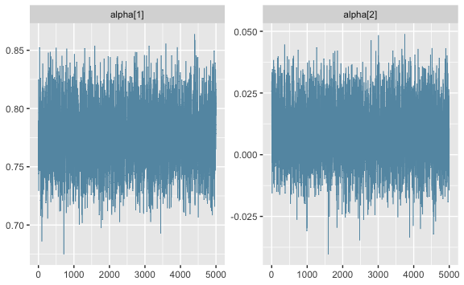

```r
autoplot(inf_bvar, type = "trace", pars = c("alpha[1]", "alpha[2]"))
```